# Analysis of N-Gram Frequencies

Ivan Lysiuchenko

August 19, 2018

## Extracting Frequency Information

We suppose that the document-feature matrices for our corpora are already computed and stored in a specific place (see the code).

This is the function we use to extract the vector of frequencies. Frequencies are sorted in descending order.

```r
loadFrequencies <- function(pathName, freqPathname, update = FALSE)
{
    if (!file.exists(freqPathname) || update)
    {
        matrCon <- file(pathName, "r")
        partMatr <- unserialize(matrCon)
        close(matrCon)
        # group all the rows, just in case
        partMatr <- dfm_group(partMatr, groups = rep(1, nrow(partMatr)))
        # sort the features by frequency
        partMatr <- dfm_sort(partMatr);

        freqs <- colSums(partMatr)
        freqCon <- file(freqPathname, "w")
        serialize(freqs, freqCon)
        close(freqCon)

        freqs
    }
    else
    {
        freqCon <- file(freqPathname, "r")
        freqs <- unserialize(freqCon)
        close(freqCon)

        freqs
    }
}
```

## Frequencies of words, bigrams and trigrams in the entire corpus

Here we explore how frequently different terms occur in the merged corpus comprising the texts from blogs, news and twits. Let’s take a look at words first.

Our preprocessing step detected 784149 different words. All of them account for 9.939417110^{7} entries. The most frequent words are the following:

```
##     the      to     and       a      of       i      in     for      is
## 4765950 2754529 2414931 2382339 2005507 1653914 1646168 1099450 1075203
##    that     you      it      on    with     was      my      at      be
## 1041899  942074  917586  818189  714646  624566  604573  571014  548300
##    this    have
##  544984  530601
```

Examples of unfrequent words:

```
##                  beleib        elasticbeanbeard                 be_____
##                       1                       1                       1
##           nodaysoff_atc online-personal-storage              oooohhhhhh
##                       1                       1                       1
##              banana-how             updyke-type          stakes-winning
##                       1                       1                       1
##              bailjumper
##                       1
```

It turns out that to cover 90% of all word usages we need to keep 7703 of the most frequent words. 50% is covered by 139 of them.

The number of different bigrams is 13302455, the overall number of their entries is 9.13159510^{7}. 90% and 50% of the entries correspond to 4.1708610^{6} and 3.509910^{4} most frequent bigrams. The most frequent bigrams are the following:

```
##   of_the   in_the   to_the  for_the   on_the    to_be   at_the  and_the
##   429895   407258   212966   200790   196143   161986   142363   125694
##     in_a with_the     is_a   it_was    for_a from_the   i_have    i_was
##   119043   105867   100812    96359    93748    87081    86461    86074
##    it_is    and_i   with_a  will_be
##    82235    82178    81862    81144
```

Examples of unfrequent bigrams:

```
##     euthanized_due         c_overload   comeback_atlanta
##                  1                  1                  1
## outstanding_what's         little_dui       gobble_fries
##                  1                  1                  1
##      playful_punch           is_rhonj    happy_attention
##                  1                  1                  1
##    affection_treat
##                  1
```

At the preprocessing step we filtered out the less frequent trigrams. Now we keep 10567515 of different features. These features account for 5.027175810^{7} entries. The most frequent trigrams are the following:

```
##         one_of_the           a_lot_of     thanks_for_the
##              34612              30056              23832
##            to_be_a        going_to_be          i_want_to
##              18184              17441              15070
##         the_end_of         out_of_the           it_was_a
##              14925              14765              14295
##         as_well_as        some_of_the         be_able_to
##              13894              13658              13068
##        part_of_the           i_have_a          i_have_to
##              12356              11856              11281
##        the_rest_of looking_forward_to       i_don't_know
##              11240              11232              11121
##      thank_you_for        is_going_to
##              10253              10165
```

Among our fitered trigrams, these are the less frequent:

```
##             barack_at_tonight's     at_tonight's_correspondents
##                               1                               1
## tonight's_correspondents_dinner                    he_is_jordan
##                               1                               1
##       correspondents_dinner_for                   jordan_and_is
##                               1                               1
##                     i_am_writin                     am_writin_a
##                               1                               1
##                   writin_a_song                to_act_exhausted
##                               1                               1
```

Let’s show the frequencies of the words, bigrams and trigrams on the same graph, using a logarithmic scale.

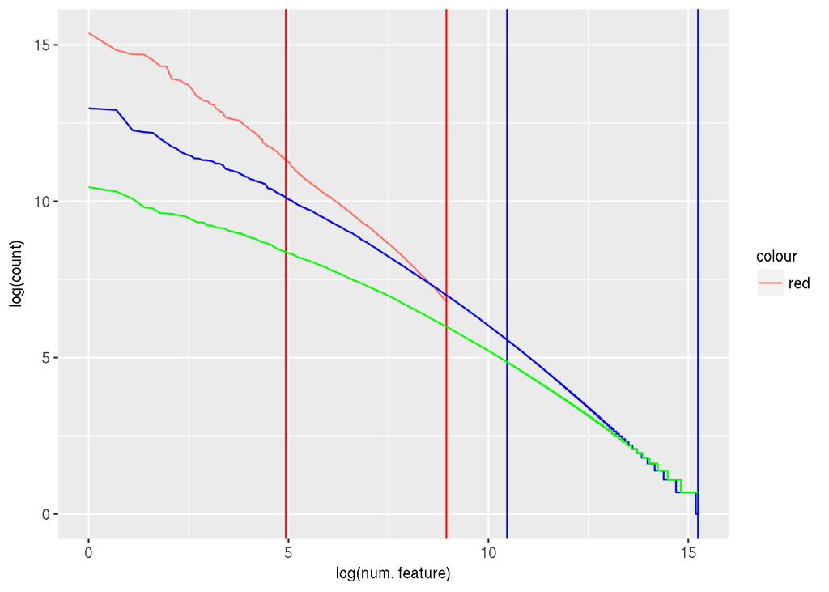